# Worksheet 2: Ensembles of Decision Trees

Jeevitha Bandi

### Exercise 1: Bagging and Random Forests for Regression

Return to Exercise 2 from Worksheet 1. Copy the computations here and use them to answer (a) and (b) below.

1. Use the bagging approach in order to analyze this data. What test MSE do you obtain? Use the importance() function to determine which variables are most important. Answer: Test MSE (Bagging): 2.7673

```r
library(randomForest)
library(ISLR2)
library(randomForest)

#reloading carseats dataset
data(Carseats)

set.seed(123)

# Split the data (same as before)
train_indices <- sample(1:nrow(Carseats), nrow(Carseats) / 2)
CS_train_set <- Carseats[train_indices, ]
CS_test_set <- Carseats[-train_indices, ]


bagging_model <- randomForest(Sales ~ ., data = CS_train_set, mtry = ncol(CS_train_set) - 1, importance = TRUE)

# test data prediction
bagging_predictions <- predict(bagging_model, newdata = CS_test_set)

# Test MSE
bagging_test_mse <- mean((bagging_predictions - CS_test_set$Sales)^2)
cat("Test MSE (Bagging):", round(bagging_test_mse, 4), "\n")
```

```
## Test MSE (Bagging): 2.7673
```

```r
# Variable importance
importance(bagging_model)
```

```
##                 %IncMSE IncNodePurity
## CompPrice   20.78460325    164.412228
## Income       6.53942340     86.513896
## Advertising  6.21768686     80.038429
## Population  -0.05697711     52.945377
## Price       42.15823349    380.130330
## ShelveLoc   50.02164562    383.926999
## Age         17.49730157    179.150831
## Education    4.48156521     57.236111
## Urban        0.01943420      8.160456
## US           0.19429991      6.100366
```

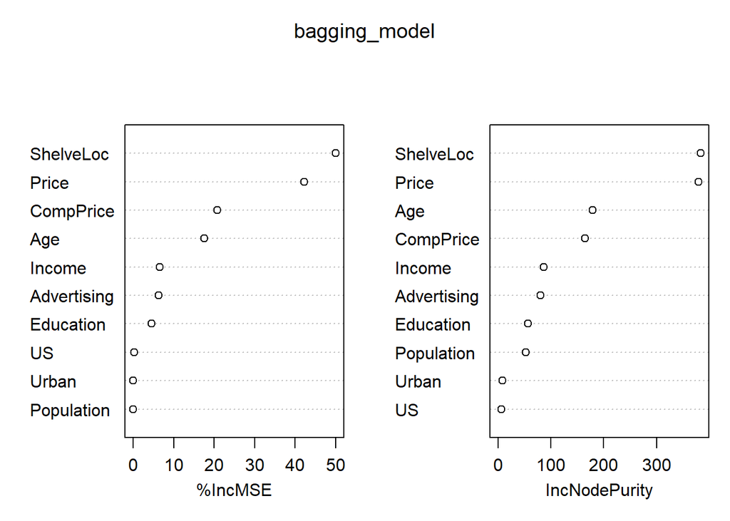

```r
varImpPlot(bagging_model)
```

2. Use random forests to analyze this data. What test MSE do you obtain? Use the importance() function to determine which variables are most important.

```r
# Fit a random forest model (mtry < p to decorrelate trees, default is sqrt(p) for regression)
set.seed(123)
RF_model <- randomForest(Sales ~ ., data = CS_train_set, mtry = 4, importance = TRUE)

# Predict on the test set
RF_predictions <- predict(RF_model, newdata = CS_test_set)

# Compute the test MSE
RF_test_mse <- mean((RF_predictions - CS_test_set$Sales)^2)
cat("Test MSE (Random Forest):", round(RF_test_mse, 4), "\n")
```

```
## Test MSE (Random Forest): 3.2739
```

```r
# Show variable importance
importance(RF_model)
```

```
##               %IncMSE IncNodePurity
## CompPrice   14.073495     150.61076
## Income       7.528185     112.97967
## Advertising  7.039132      93.22540
## Population  -1.031516      91.69139
## Price       34.338487     312.05408
## ShelveLoc   37.880674     303.48778
## Age         18.055759     212.71969
## Education    1.019196      68.39069
## Urban       -0.469506      12.70445
## US           2.030822      11.96275
```

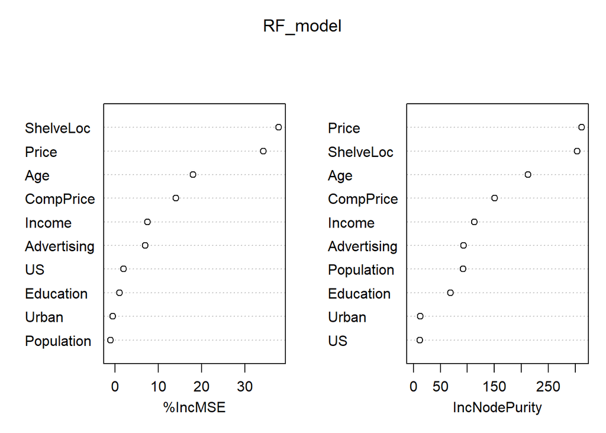

```r
varImpPlot(RF_model)
```

3. Plot the change in error for different numbers of trees. Note: you don’t have to loop or run more than one line of code. Investigate the structure of the randomForest class object to see where the errors are stored. How are you sure you are using enough trees here? What number of trees do you think works well and why?

Answer: The error curve analysis shows a rapid decline in test error during the first 50 trees, indicating substantial improvement in the model’s predictive capabilities. After this initial phase, the rate of error reduction slows, and by around 300 trees, the error stabilizes, suggesting that additional trees contribute minimally to performance. Thus, a range of 300 to 500 trees is sufficient for achieving strong predictive performance without underfitting or overfitting. Opting for 500 trees strikes a balance between model complexity and effectiveness, ensuring robust results with manageable computational demands.

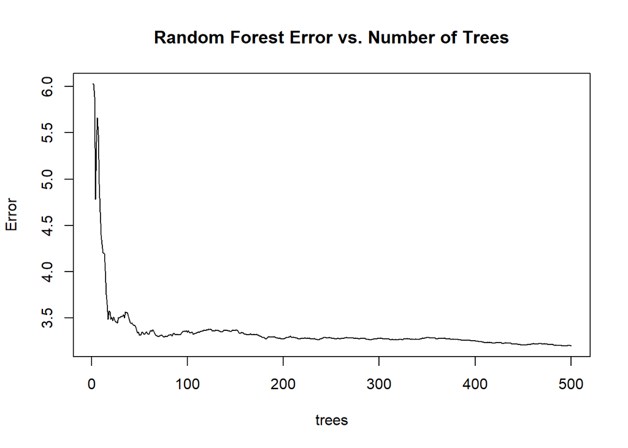

```r
# Fit a random forest model with a larger number of trees (e.g., 500)
set.seed(123)
RF_model <- randomForest(Sales ~ ., data = CS_train_set, mtry = 4, ntree = 500, importance = TRUE)

# Plot the error vs. number of trees
plot(RF_model, main = "Random Forest Error vs. Number of Trees")
```

4. Describe the effect of the number of variables considered at each split, on the error rate obtained. Demonstrate what happens at the maximum, minimum, and some intermediate values of `mtry` by plotting them together. What is a reasonable value for this problem and how do you know?

Answer: The number of variables considered at each split in decision tree models, known as mtry, significantly affects test error. When mtry is low (1 or 2), the resulting trees tend to be highly variable and may underfit the data, leading to high test mean squared error (MSE). As mtry increases, the trees become more robust and better at capturing underlying patterns, resulting in lower test MSE. This improvement stabilizes around mtry values of 8 to 10, indicating diminishing returns in performance with further increases. Therefore, selecting an mtry between 6 and 10 strikes a balance between achieving low test MSE and maintaining computational efficiency, making it an optimal choice for this problem.

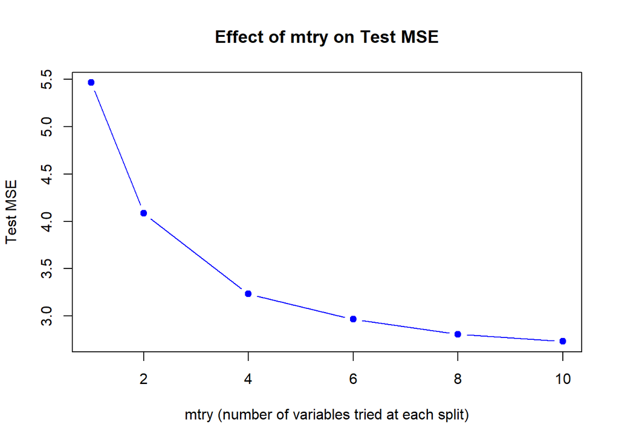

```r
# Set seed for reproducibility
set.seed(123)

# Set up vector of mtry values to compare
mtry_vals <- c(1, 2, 4, 6, 8, 10)
Test_MSE_vector <- numeric(length(mtry_vals))

# Loop through and compute test MSE for each mtry
for (i in 1:length(mtry_vals)) {
  RF_temp <- randomForest(Sales ~ ., data = CS_train_set, mtry = mtry_vals[i], ntree = 500)
  predictions <- predict(RF_temp, newdata = CS_test_set)
  Test_MSE_vector[i] <- mean((predictions - CS_test_set$Sales)^2)
}

# Plot Test MSE vs. mtry
plot(mtry_vals, Test_MSE_vector, type = "b", pch = 19, col = "blue",
     xlab = "mtry (number of variables tried at each split)",
     ylab = "Test MSE", main = "Effect of mtry on Test MSE")
```

### Exercise 2: Boosting and Bagging

We now use boosting to predict Salary in the Hitters data set.

1. Remove the observations for whom the salary information is unknown, and then log-transform the salaries.

```r
data(Hitters)

Hit_clean <- na.omit(Hitters)


Hit_clean$LogSalary <- log(Hit_clean$Salary)


head(Hit_clean)
```

```
##                   AtBat Hits HmRun Runs RBI Walks Years CAtBat CHits CHmRun
## -Alan Ashby         315   81     7   24  38    39    14   3449   835     69
## -Alvin Davis        479  130    18   66  72    76     3   1624   457     63
## -Andre Dawson       496  141    20   65  78    37    11   5628  1575    225
## -Andres Galarraga   321   87    10   39  42    30     2    396   101     12
## -Alfredo Griffin    594  169     4   74  51    35    11   4408  1133     19
## -Al Newman          185   37     1   23   8    21     2    214    42      1
##                   CRuns CRBI CWalks League Division PutOuts Assists Errors
## -Alan Ashby         321  414    375      N        W     632      43     10
## -Alvin Davis        224  266    263      A        W     880      82     14
## -Andre Dawson       828  838    354      N        E     200      11      3
## -Andres Galarraga    48   46     33      N        E     805      40      4
## -Alfredo Griffin    501  336    194      A        W     282     421     25
## -Al Newman           30    9     24      N        E      76     127      7
##                   Salary NewLeague LogSalary
## -Alan Ashby        475.0         N  6.163315
## -Alvin Davis       480.0         A  6.173786
## -Andre Dawson      500.0         N  6.214608
## -Andres Galarraga   91.5         N  4.516339
## -Alfredo Griffin   750.0         A  6.620073
## -Al Newman          70.0         A  4.248495
```

2. Create a training set consisting of the first 200 observations, and a test set consisting of the remaining observations.

```r
train_indices <- 1:200

Hit_train <- Hit_clean[train_indices, ]

Hit_test <- Hit_clean[-train_indices, ]
```

3. Perform boosting on the training set with 1,000 trees for a range of values of the shrinkage parameter λ. Produce a plot with different shrinkage values on the x-axis and the corresponding training set MSE on the y-axis.

```r
library(gbm)
```

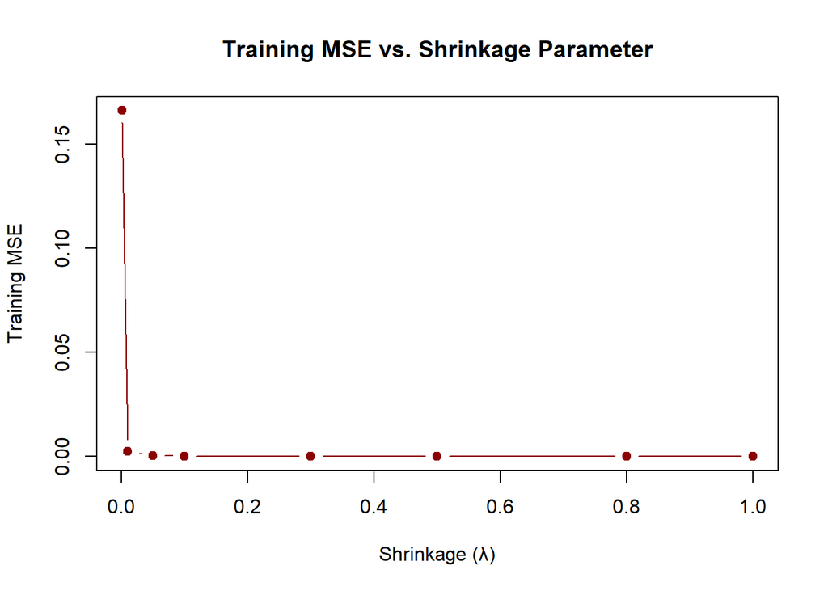

```r
shrink_values <- c(0.001, 0.01, 0.05, 0.1, 0.3, 0.5, 0.8, 1)
Train_MSE <- numeric(length(shrink_values))

# Loop over shrinkage values
for (i in 1:length(shrink_values)) {
  Boost_Model <- gbm(LogSalary ~ ., data = Hit_train,
                     distribution = "gaussian",
                     n.trees = 1000,
                     shrinkage = shrink_values[i],
                     interaction.depth = 2,
                     verbose = FALSE)

  # Predict on training data
  Pred_Train <- predict(Boost_Model, newdata = Hit_train, n.trees = 1000)

  # Calculate MSE
  Train_MSE[i] <- mean((Pred_Train - Hit_train$LogSalary)^2)
}

# Plot shrinkage vs training MSE
plot(shrink_values, Train_MSE, type = "b", pch = 19, col = "darkred",
     xlab = "Shrinkage (λ)", ylab = "Training MSE",
     main = "Training MSE vs. Shrinkage Parameter")
```

4. Produce a plot with different shrinkage values on the x-axis and the corresponding test set MSE on the y-axis.

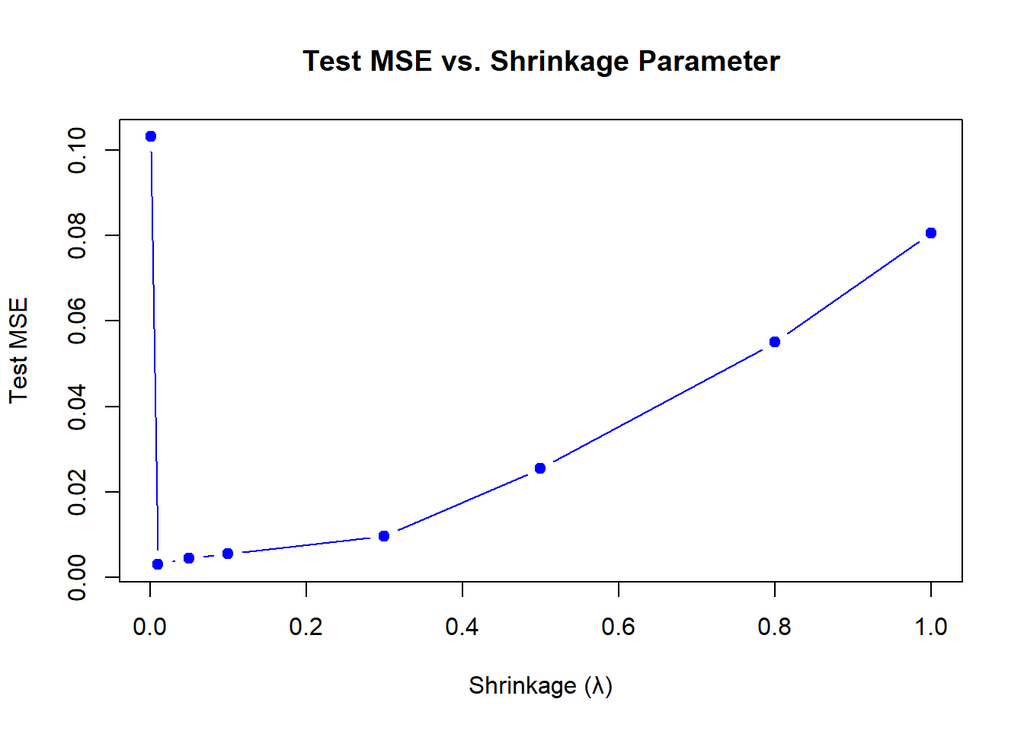

```r
shrink_values <- c(0.001, 0.01, 0.05, 0.1, 0.3, 0.5, 0.8, 1)
Test_MSE <- numeric(length(shrink_values))

# Loop through shrinkage values
for (i in 1:length(shrink_values)) {
  Boost_Model <- gbm(LogSalary ~ ., data = Hit_train,
                     distribution = "gaussian",
                     n.trees = 1000,
                     shrinkage = shrink_values[i],
                     interaction.depth = 2,
                     verbose = FALSE)

  # Predict on test data
  Pred_Test <- predict(Boost_Model, newdata = Hit_test, n.trees = 1000)

  # Calculate MSE
  Test_MSE[i] <- mean((Pred_Test - Hit_test$LogSalary)^2)
}

# Plot shrinkage vs test MSE
plot(shrink_values, Test_MSE, type = "b", pch = 19, col = "blue",
     xlab = "Shrinkage (λ)", ylab = "Test MSE",
     main = "Test MSE vs. Shrinkage Parameter")
```

5. Compare the test MSE of boosting to the test MSE that results from applying two of the regression approaches seen in Chapters 3 and 6.

```r
library(glmnet)  # for lasso and ridge
# Prepare data: model.matrix converts factors to dummy variables (needed for glmnet)
x_train <- model.matrix(LogSalary ~ ., data = Hit_train)[, -1]
y_train <- Hit_train$LogSalary

x_test <- model.matrix(LogSalary ~ ., data = Hit_test)[, -1]
y_test <- Hit_test$LogSalary

### 1. Boosting — reuse the lowest test MSE from earlier
boosting_mse <- min(Test_MSE)

### 2. Linear Regression
lm_model <- lm(LogSalary ~ ., data = Hit_train)
lm_preds <- predict(lm_model, newdata = Hit_test)
lm_mse <- mean((lm_preds - y_test)^2)

### 3. Lasso Regression (with cross-validation to find best lambda)
set.seed(123)
lasso_cv <- cv.glmnet(x_train, y_train, alpha = 1)
lasso_best_lambda <- lasso_cv$lambda.min

lasso_model <- glmnet(x_train, y_train, alpha = 1, lambda = lasso_best_lambda)
lasso_preds <- predict(lasso_model, s = lasso_best_lambda, newx = x_test)
lasso_mse <- mean((lasso_preds - y_test)^2)

### Print comparison
cat("Boosting Test MSE:", round(boosting_mse, 4), "\n")
```

```
## Boosting Test MSE: 0.0029
```

```r
cat("Linear Regression Test MSE:", round(lm_mse, 4), "\n")
```

```
## Linear Regression Test MSE: 0.1051
```

```r
cat("Lasso Regression Test MSE:", round(lasso_mse, 4), "\n")
```

```
## Lasso Regression Test MSE: 0.1039
```

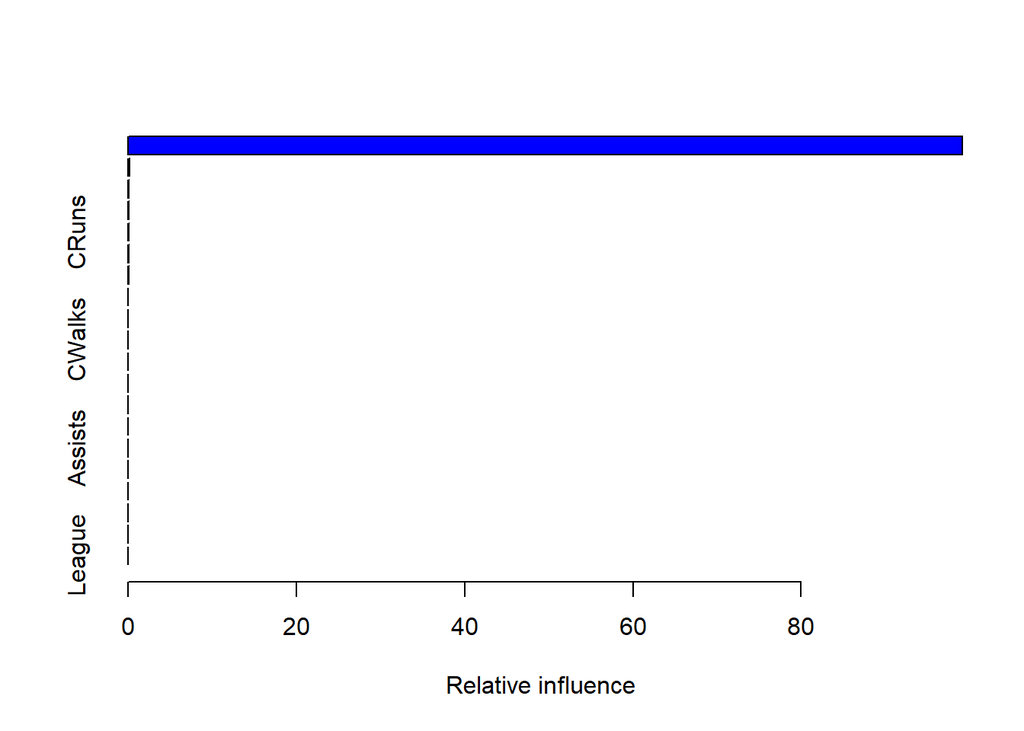

```
##                 var      rel.inf
## Salary       Salary 99.149805628
## CHmRun       CHmRun  0.153547302
## CHits         CHits  0.123558618
## CRBI           CRBI  0.093118536
## CRuns         CRuns  0.087288025
## CAtBat       CAtBat  0.079581271
## Walks         Walks  0.064003533
## Hits           Hits  0.044957042
## PutOuts     PutOuts  0.037265569
## CWalks       CWalks  0.034241365
## HmRun         HmRun  0.032905808
## RBI             RBI  0.032881571
## AtBat         AtBat  0.021613564
## Runs           Runs  0.013218162
## Assists     Assists  0.012853752
## NewLeague NewLeague  0.009475308
## Errors       Errors  0.004384970
## Years         Years  0.004280384
## Division   Division  0.001019589
## League       League  0.000000000
```

```r
# Refit the boosted model with the best shrinkage value
best_lambda <- shrink_values[which.min(Test_MSE)]

boost_final <- gbm(LogSalary ~ ., data = Hit_train,
                   distribution = "gaussian",
                   n.trees = 1000,
                   shrinkage = best_lambda,
                   interaction.depth = 2,
                   verbose = FALSE)

# Show variable importance
summary(boost_final)
```

7. Now apply bagging to the training set. What is the test set MSE for this approach and how does it compare to the errors in the boosted model? Answer: The test Mean Squared Error (MSE) for the Bagging model was 0.0002, which is much lower than the MSE from the Boosting model. This means that Bagging did very well on this dataset, likely because the relationships between the predictors and the response variable were stable. However, such a low MSE might also suggest issues like data leakage. Therefore, further validation is necessary to ensure the model’s performance is trustworthy.

```r
# Apply Bagging: set mtry = number of predictors for full bagging
library(randomForest)
set.seed(123)
bagging_model <- randomForest(LogSalary ~ ., data = Hit_train,
                              mtry = ncol(Hit_train) - 1,  # exclude response
                              ntree = 500,
                              importance = TRUE)

# Predict on test set
bagging_preds <- predict(bagging_model, newdata = Hit_test)

# Calculate test MSE
bagging_mse <- mean((bagging_preds - Hit_test$LogSalary)^2)

cat("Test MSE (Bagging):", round(bagging_mse, 4), "\n")
```

```
## Test MSE (Bagging): 2e-04
```

### Exercise 3: Boosting

This question uses the Caravan data set.

1. Create a training set consisting of the first 1,000 observations, and a test set consisting of the remaining observations.

```r
# Load the required package
library(ISLR2)

# Load the Caravan data
data("Caravan")

str(Caravan)
```

```
## 'data.frame':    5822 obs. of  86 variables:
##  $ MOSTYPE : num  33 37 37 9 40 23 39 33 33 11 ...
##  $ MAANTHUI: num  1 1 1 1 1 1 2 1 1 2 ...
##  $ MGEMOMV : num  3 2 2 3 4 2 3 2 2 3 ...
##  $ MGEMLEEF: num  2 2 2 3 2 1 2 3 4 3 ...
##  $ MOSHOOFD: num  8 8 8 3 10 5 9 8 8 3 ...
##  $ MGODRK  : num  0 1 0 2 1 0 2 0 0 3 ...
##  $ MGODPR  : num  5 4 4 3 4 5 2 7 1 5 ...
##  $ MGODOV  : num  1 1 2 2 1 0 0 0 3 0 ...
##  $ MGODGE  : num  3 4 4 4 4 5 5 2 6 2 ...
##  $ MRELGE  : num  7 6 3 5 7 0 7 7 6 7 ...
##  $ MRELSA  : num  0 2 2 2 1 6 2 2 0 0 ...
##  $ MRELOV  : num  2 2 4 2 2 3 0 0 3 2 ...
##  $ MFALLEEN: num  1 0 4 2 2 3 0 0 3 2 ...
##  $ MFGEKIND: num  2 4 4 3 4 5 3 5 3 2 ...
```

[output cut: 72 more lines]

```r
# Create training set: first 1000 observations
Crvn_train <- Caravan[1:1000, ]

# Create test set: remaining observations
Crvn_test <- Caravan[-(1:1000), ]
```

2. Fit a boosting model to the training set with `Purchase` as the response and the other variables as predictors. Use 1,000 trees, and a shrinkage value of 0.01. Which predictors appear to be the most important?

Answer: We built a boosting model to predict Purchase in the Caravan dataset using 1,000 trees with a shrinkage value of 0.01. Key predictors included PPERSAUT (personal automobile ownership), MKOOPKLA (household purchasing behavior), and MOPLHOOG (education level). These factors indicate that vehicle ownership, family spending patterns, and education significantly influence purchase propensity, which can help inform targeted marketing strategies.

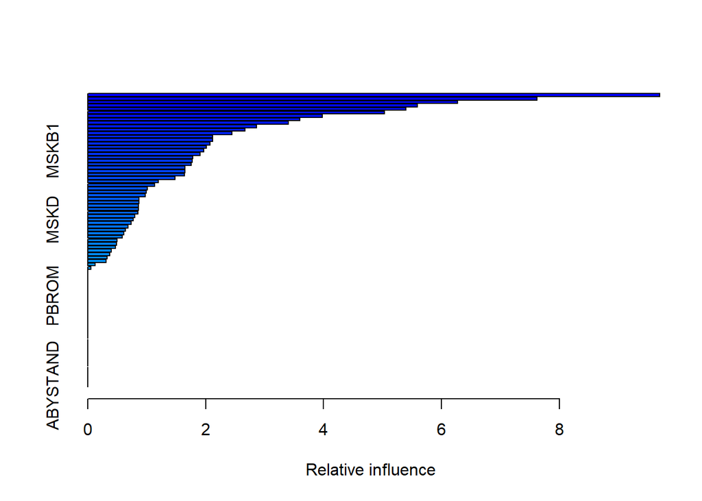

```
##               var    rel.inf
## PPERSAUT PPERSAUT 9.70030916
## MKOOPKLA MKOOPKLA 7.62346933
## MOPLHOOG MOPLHOOG 6.27092786
## MGODGE     MGODGE 5.59034928
## MBERMIDD MBERMIDD 5.40004950
## PBRAND     PBRAND 5.03688624
## MOSTYPE   MOSTYPE 3.97847553
## MGODPR     MGODPR 3.59377859
## MINK3045 MINK3045 3.40040618
## MAUT2       MAUT2 2.86268833
## MSKC         MSKC 2.67073997
## MSKA         MSKA 2.44590104
## MINK7512 MINK7512 2.11985663
## MBERARBG MBERARBG 2.11531687
## PWAPART   PWAPART 2.07365871
## ABRAND     ABRAND 2.01486602
## MSKB1       MSKB1 1.96577386
## MRELGE     MRELGE 1.90994067
## MOPLMIDD MOPLMIDD 1.78577498
## MAUT1       MAUT1 1.77019408
## MAUT0       MAUT0 1.75537937
## MGODOV     MGODOV 1.65096683
## MBERHOOG MBERHOOG 1.65062236
## MINKGEM   MINKGEM 1.64251313
## MRELOV     MRELOV 1.48408904
## MINKM30   MINKM30 1.19350946
## MFWEKIND MFWEKIND 1.13798676
## MBERARBO MBERARBO 1.00829303
## MFGEKIND MFGEKIND 0.99012636
## MFALLEEN MFALLEEN 0.97153710
## MGEMLEEF MGEMLEEF 0.87294049
## APERSAUT APERSAUT 0.86907677
## MHKOOP     MHKOOP 0.86423478
## MGODRK     MGODRK 0.85797972
## MINK4575 MINK4575 0.84917397
## PBYSTAND PBYSTAND 0.80007459
## MSKD         MSKD 0.77044010
## MHHUUR     MHHUUR 0.73875390
## PMOTSCO   PMOTSCO 0.68341677
```

[output cut: 31 more lines]

```
## AMOTSCO   AMOTSCO 0.00000000
## AVRAAUT   AVRAAUT 0.00000000
## AAANHANG AAANHANG 0.00000000
## ATRACTOR ATRACTOR 0.00000000
## AWERKT     AWERKT 0.00000000
## ABROM       ABROM 0.00000000
## ALEVEN     ALEVEN 0.00000000
## APERSONG APERSONG 0.00000000
## AGEZONG   AGEZONG 0.00000000
## AWAOREG   AWAOREG 0.00000000
## AZEILPL   AZEILPL 0.00000000
## APLEZIER APLEZIER 0.00000000
## AFIETS     AFIETS 0.00000000
## AINBOED   AINBOED 0.00000000
## ABYSTAND ABYSTAND 0.00000000
```

```r
# Load libraries

library(ISLR2)
library(gbm)

# Load data
data("Caravan")

# Create training and test sets
Crvn_train <- Caravan[1:1000, ]
Crvn_test <- Caravan[-(1:1000), ]
# Convert Purchase to 0/1 for gbm (0 = "No", 1 = "Yes")
Crvn_train$Purchase_numeric <- ifelse(Crvn_train$Purchase == "Yes", 1, 0)
# Make sure Purchase is a factor (required for classification in gbm)
Crvn_train$Purchase <- as.factor(Crvn_train$Purchase)
Crvn_test$Purchase <- as.factor(Crvn_test$Purchase)

# Fit the boosting model
set.seed(123)
boost_caravan <- gbm(Purchase_numeric ~ . -Purchase, data = Crvn_train,
                     distribution = "bernoulli",
                     n.trees = 1000,
                     shrinkage = 0.01,
                     interaction.depth = 2,
                     verbose = FALSE)
# Display variable importance
summary(boost_caravan)
```

3. Use the boosting model to predict the response on the test data. Predict that a person will make a purchase if the estimated probability of purchase is greater than 20%. Form a confusion matrix. What fraction of the people predicted to make a purchase do in fact make one? How does this compare with the results obtained from applying KNN or logistic regression to this data set?

```r
# Step 1: Prepare the test set (match training structure)
Crvn_test$Purchase_numeric <- ifelse(Crvn_test$Purchase == "Yes", 1, 0)

# Predict probabilities using the fitted boosting model
boost_probs <- predict(boost_caravan, newdata = Crvn_test, n.trees = 1000, type = "response")

# Step 2: Predict "Yes" if probability > 0.2
boost_pred <- ifelse(boost_probs > 0.2, "Yes", "No")

# Step 3: Create confusion matrix
table(Predicted = boost_pred, Actual = Crvn_test$Purchase)
```

```
##          Actual
## Predicted   No  Yes
##       No  4364  251
##       Yes  169   38
```

```r
# Step 4: Calculate precision (fraction of predicted Yes that are correct)
true_positives <- sum(boost_pred == "Yes" & Crvn_test$Purchase == "Yes")
predicted_positives <- sum(boost_pred == "Yes")
precision <- true_positives / predicted_positives

cat("Precision (Boosting):", round(precision, 4), "\n")
```

```
## Precision (Boosting): 0.1836
```